# Prediction Assignment Writeup

jp

04/18/2015

# Overview

The data for this project come from this source: http://groupware.les.inf.puc-rio.br/har. The goal of this project is to create a model that will predict the manner in which subjects did their exercise, as noted in the “classe” variable in the training set.

# Exploratory Analysis

```r
colclasses <- c("NULL", "factor", "NULL", "NULL", "NULL", "NULL", "NULL", "numeric", "numeric", "numeric", "numeric", "NULL", "NULL", "NULL", "NULL", "NULL", "NULL", "NULL", "NULL", "NULL", "NULL", "NULL", "NULL", "NULL", "NULL", "NULL", "NULL", "NULL", "NULL", "NULL", "NULL", "NULL", "NULL", "NULL", "NULL", "NULL", "numeric", "numeric", "numeric", "numeric", "numeric", "numeric", "numeric", "numeric", "numeric", "numeric", "numeric", "numeric", "numeric", "NULL", "NULL", "NULL", "NULL", "NULL", "NULL", "NULL", "NULL", "NULL", "NULL", "numeric", "numeric", "numeric", "numeric", "numeric", "numeric", "numeric", "numeric", "numeric", "NULL", "NULL", "NULL", "NULL", "NULL", "NULL", "NULL", "NULL", "NULL", "NULL", "NULL", "NULL", "NULL", "NULL", "NULL", "numeric", "numeric", "numeric", "NULL", "NULL", "NULL", "NULL", "NULL", "NULL", "NULL", "NULL", "NULL", "NULL", "NULL", "NULL", "NULL", "NULL", "NULL", "numeric", "NULL", "NULL", "NULL", "NULL", "NULL", "NULL", "NULL", "NULL", "NULL", "NULL", "numeric", "numeric", "numeric", "numeric", "numeric", "numeric", "numeric", "numeric", "numeric", "numeric", "numeric", "numeric", "NULL", "NULL", "NULL", "NULL", "NULL", "NULL", "NULL", "NULL", "NULL", "NULL", "NULL", "NULL", "NULL", "NULL", "NULL", "numeric", "NULL", "NULL", "NULL", "NULL", "NULL", "NULL", "NULL", "NULL", "NULL", "NULL", "numeric", "numeric", "numeric", "numeric", "numeric", "numeric", "numeric", "numeric", "numeric", "factor")
pmltraining = read.csv("C:/_dev/R/machlearn/pml-training.csv", header=TRUE, colClasses=colclasses)
library(caret)
set.seed(4582)
inTrain<-createDataPartition(y=pmltraining$classe,p=.7,list=FALSE)
training<-pmltraining[inTrain,]
testing<-pmltraining[-inTrain,]
```

There is variability across all columns of the data, so we will retain all for the model.

```r
nsv <- nearZeroVar(training, saveMetrics=TRUE)
nsv[which(nsv$nzv),]
```

```
## [1] freqRatio     percentUnique zeroVar       nzv
## <0 rows> (or 0-length row.names)
```

We can look at correlations across the variables for some exploratory analysis.

```r
M <- abs(cor(training[,2:53]))
diag(M) <- 0
which(M > 0.8,arr.ind=T)
```

```
##                  row col
## yaw_belt           3   1
## total_accel_belt   4   1
## accel_belt_y       9   1
## accel_belt_z      10   1
## accel_belt_x       8   2
## magnet_belt_x     11   2
## roll_belt          1   3
## roll_belt          1   4
## accel_belt_y       9   4
## accel_belt_z      10   4
## pitch_belt         2   8
## magnet_belt_x     11   8
## roll_belt          1   9
## total_accel_belt   4   9
## accel_belt_z      10   9
## roll_belt          1  10
## total_accel_belt   4  10
## accel_belt_y       9  10
## pitch_belt         2  11
## accel_belt_x       8  11
## gyros_arm_y       19  18
## gyros_arm_x       18  19
## magnet_arm_x      24  21
## accel_arm_x       21  24
## magnet_arm_z      26  25
## magnet_arm_y      25  26
## accel_dumbbell_x  34  28
## accel_dumbbell_z  36  29
## gyros_dumbbell_z  33  31
## gyros_forearm_z   46  31
## gyros_dumbbell_x  31  33
## gyros_forearm_z   46  33
## pitch_dumbbell    28  34
## yaw_dumbbell      29  36
## gyros_forearm_z   46  45
## gyros_dumbbell_x  31  46
## gyros_dumbbell_z  33  46
## gyros_forearm_y   45  46
```

Some of the variables are corellated across classes and users. This may be because some lifting movements incur changes across multiple axes, and because the pitch, yaw and roll are derived directly from the sensor data across the respective axes. These are the groupings suggested by the correlations: 1) yaw_belt, total_accel_belt, accel_belt_y, accel_belt_z, roll_belt; 2) pitch_belt, accel_belt_x, magnet_belt_x; 3) gyros_arm_y, gyros_arm_x; 4) magnet_arm_x, accel_arm_x; 5) magnet_arm_z, magnet_arm_y; 6) accel_dumbbell_x, pitch_dumbell; 7) accel_dumbbell_z, yaw_dumbbell.

# Modeling

The correlations suggest that we should use Principal Component Analysis to compress the correlated columns and simplify the model. However, the error rate on a Random Forest based on a PCA shows enough expected error to be significant in the context of the assignment.

```r
# Create random forest on a principal component analysis
library(randomForest)
set.seed(4582)
prComp <- prcomp(training[,2:53])
training.pc <- predict(prComp, training)
training.pcrf <- randomForest(training.pc, y=training$classe)
training.pcrf
```

```
##
## Call:
##  randomForest(x = training.pc, y = training$classe)
##                Type of random forest: classification
##                      Number of trees: 500
## No. of variables tried at each split: 7
##
##         OOB estimate of  error rate: 2.01%
## Confusion matrix:
##      A    B    C    D    E class.error
## A 3899    2    1    3    1 0.001792115
## B   62 2567   21    0    8 0.034236268
## C    3   40 2341    6    6 0.022954925
## D    4    2   84 2153    9 0.043960924
## E    1    8    8    7 2501 0.009504950
```

A Random Forest based on the raw data is more accurate, and accurate enough, so we will use that instead. The importance of the variables is displayed for comparison with those correlated above.

```r
set.seed(4582)
training.rf <- randomForest(training[,2:53], y=training$classe)
training.rf
```

```
##
## Call:
##  randomForest(x = training[, 2:53], y = training$classe)
##                Type of random forest: classification
##                      Number of trees: 500
## No. of variables tried at each split: 7
##
##         OOB estimate of  error rate: 0.55%
## Confusion matrix:
##      A    B    C    D    E  class.error
## A 3903    3    0    0    0 0.0007680492
## B   15 2637    6    0    0 0.0079006772
## C    0   16 2378    2    0 0.0075125209
## D    0    0   22 2229    1 0.0102131439
## E    0    0    3    8 2514 0.0043564356
```

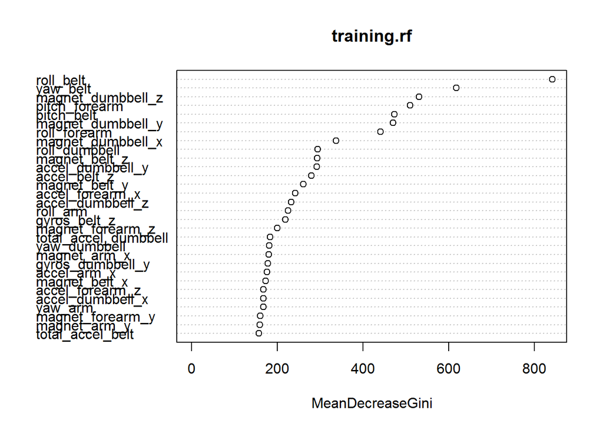

```r
varImpPlot(training.rf)
```

# Cross-validation

If we needed to process large amounts data, we could tune the random forest generation for max nodes, but the above model should suffice for the purpose of the assignment. As an example, cross-validation shows the error decreasing as number of predictors grows, up to roughly thirteen variables.

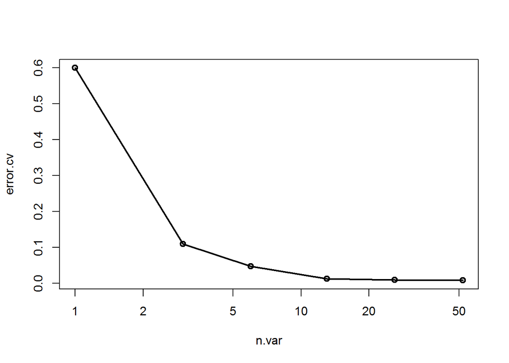

```r
set.seed(4582)
training.rfcv <- rfcv(training[,2:53], training$classe, cv.fold=5)
with(training.rfcv, plot(n.var, error.cv, log="x", type="o", lwd=2))
```

# Application to Test Set

Using our model, we can estimate our out-of-sample error rate against the test set:

```r
confusionMatrix(testing$classe, predict(training.rf, testing))
```

```
## Confusion Matrix and Statistics
##
##           Reference
## Prediction    A    B    C    D    E
##          A 1674    0    0    0    0
##          B    6 1133    0    0    0
##          C    0    3 1022    1    0
##          D    0    0    9  955    0
##          E    0    0    3    0 1079
##
## Overall Statistics
##
##                Accuracy : 0.9963
##                  95% CI : (0.9943, 0.9977)
##     No Information Rate : 0.2855
##     P-Value [Acc > NIR] : < 2.2e-16
##
##                   Kappa : 0.9953
##  Mcnemar's Test P-Value : NA
##
## Statistics by Class:
##
##                      Class: A Class: B Class: C Class: D Class: E
## Sensitivity            0.9964   0.9974   0.9884   0.9990   1.0000
## Specificity            1.0000   0.9987   0.9992   0.9982   0.9994
## Pos Pred Value         1.0000   0.9947   0.9961   0.9907   0.9972
## Neg Pred Value         0.9986   0.9994   0.9975   0.9998   1.0000
## Prevalence             0.2855   0.1930   0.1757   0.1624   0.1833
## Detection Rate         0.2845   0.1925   0.1737   0.1623   0.1833
## Detection Prevalence   0.2845   0.1935   0.1743   0.1638   0.1839
## Balanced Accuracy      0.9982   0.9980   0.9938   0.9986   0.9997
```